# Reproducible Research: Peer Assessment 1

Welcome to my Peer Review Assignment 1 for Reproducible Research class.

Make sure the working directory is set to the location of the activity.csv file.

First off the activity.csv file is read in.

```r
library("lattice")

datafile <- "activity.csv"
datafile <- paste0(getwd(), "/", datafile)

stepdata <- read.csv(datafile, header = TRUE, comment.char = "")
```

A column is added to combine the date and time fields into a single POSIX format date number. Additionally a column is added to hold a logical TRUE value if the steps field is marked na, FALSE otherwise.

```r
stepdata$datetime <- as.POSIXct(paste(stepdata$date, stepdata$interval%/%100,
                                      stepdata$interval%%100),
                                "%Y-%m-%d %H %M", tz = "GMT")
stepdata$isna <- is.na(stepdata$steps)
```

## Mean Total Number of Steps per Day

tapply is used to sum the total steps for each day, na’s are removed before summing. allnas is a flag that a day consists entirely of na’s.

The following histogram shows the frequency (how many times) a day had a step total within the bar’s range. Days that had all na’s are not used in the histogram since they their sum is 0, which is not a valid count of activity for the day.

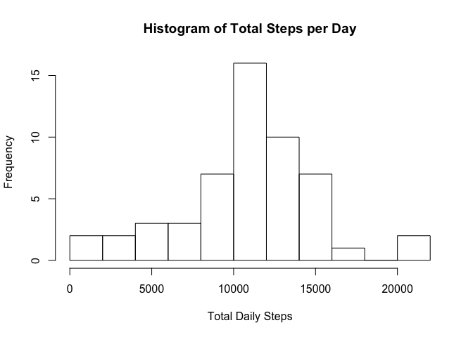

```r
dailysteps <- tapply(stepdata$steps, stepdata$date, sum, na.rm = TRUE)
allnas <- tapply(stepdata$isna, stepdata$date, all)

# don't use the days with all na's, since the sum will be 0 rather then na
hist(dailysteps[!allnas], breaks = 10,
     main = "Histogram of Total Steps per Day", xlab = "Total Daily Steps")
```

```r
cat("The mean steps per day is: ", mean(dailysteps))
```

```
## The mean steps per day is:  9354
```

```r
cat("The median steps per day is: ", median(dailysteps))
```

```
## The median steps per day is:  10395
```

```r
rm(allnas)               # housekeeping
```

## Average Daily Activity Pattern

tapply is once again used to calculate the mean number of steps taken for each time interval across all the days. The maximum activity is noted both in the graph and on a line of output.

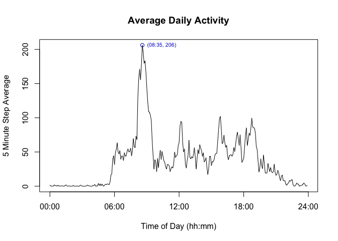

```r
steps <- tapply(stepdata$steps, stepdata$interval, mean, na.rm = TRUE)

# extract the time from the names the tapply function assigned in variable steps
# 0001-01-01 is used to mark the date as arbitrary, but not the time info
time <- as.integer(names(steps))
timePOSIX <- as.POSIXct(paste("0001-01-01", time %/% 100, time %% 100),
                   "%Y-%m-%d %H %M", tz = "GMT")
timesteps <- data.frame(steps, time, timePOSIX)

rm(steps, time, timePOSIX)         # housekeeping

timetics = as.POSIXct(c("0001-01-01 00","0001-01-01 06","0001-01-01 12",
                          "0001-01-01 18","0001-01-01 24"),
                         "%Y-%m-%d %H", tz = "GMT")

plot(timesteps$timePOSIX, timesteps$steps, type = "l", xaxt = "n",
     xlab = "Time of Day (hh:mm)", ylab = "5 Minute Step Average",
     main = "Average Daily Activity")
axis(1, at = timetics,
     labels = c("00:00","06:00","12:00","18:00","24:00"))

maxsteps <- which.max(timesteps$steps)
timeofmax <- timesteps$timePOSIX[maxsteps]
maxsteps <- timesteps$steps[maxsteps]

points(timeofmax, maxsteps, pch=1, col = "mediumblue")
text(timeofmax, maxsteps,
     paste0("(",format(timeofmax, "%H:%M"), ", ", round(maxsteps, 0), ")" ),
     pos=4 , cex = 0.67, col = "mediumblue")
```

```r
cat("On average at ", format(timeofmax, "%H:%M"), " the maximum number of steps, ", round(maxsteps, 0), ", occurred.", sep = "")
```

```
## On average at 08:35 the maximum number of steps, 206, occurred.
```

## Imputing Missing Values

A seperate data.frame is created from the original. The mean daily activity calculated above for each time interval is used to replace missing values in the original data. The code assumes that all 288 (24 * 60 / 5) time intervals are present for each day. This assumption appears to hold for this activity file since 17568 lines / 288 intervals = 61 even.

As above the number of steps for each day is again computed including the imputed data and a histogram generated.

```r
cat("There are", sum(stepdata$isna), "missing step values in the dataset")
```

```
## There are 2304 missing step values in the dataset
```

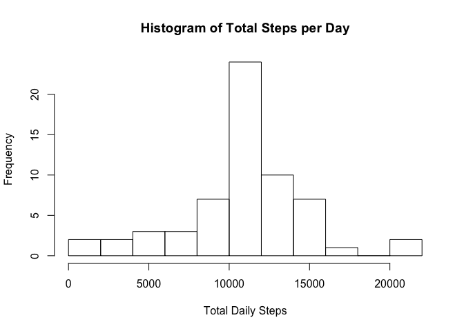

```r
imputeddata <- stepdata

# to fill in missing data use the mean for that time step.
# the entire imputedsteps column is initialized using the mean data to fill it
imputeddata$imputedsteps <- timesteps$steps

# if the data is not na, then the mean data is overwritten with the valid value
imputeddata$imputedsteps <- ifelse(imputeddata$isna,
                                   imputeddata$imputedsteps, imputeddata$steps)

dailyimputsteps <- tapply(imputeddata$imputedsteps, imputeddata$date,
                          sum, na.rm = FALSE)
hist(dailyimputsteps, breaks = 10,
     main = "Histogram of Total Steps per Day", xlab = "Total Daily Steps")
```

```r
cat("The mean steps per day is: ", mean(dailyimputsteps))
```

```
## The mean steps per day is:  10766
```

```r
cat("The median steps per day is: ", median(dailyimputsteps))
```

```
## The median steps per day is:  10766
```

## Differences in Weekday / Weekend Activity Patterns

The date is used to factor each day as a weekend or weekday. A lattice plot comparing the weekend and weekday activity is then presented.

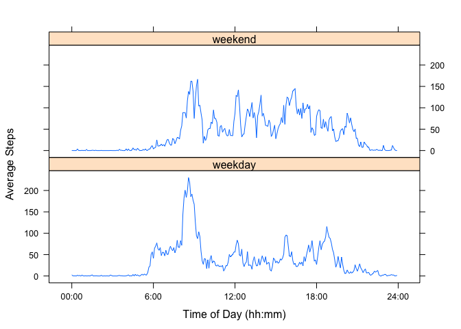

```r
# find day of week for each date, then change it to either weekday or weekend
imputeddata$weekday <- weekdays(imputeddata$datetime)
imputeddata$weekday <- ifelse(imputeddata$weekday %in% c("Saturday", "Sunday"),
                              "weekend", "weekday")
imputeddata$weekday <- as.factor(imputeddata$weekday)

# use tapply to find mean number of steps taken on weekdays and then on weekends
weekdaysteps <- tapply(imputeddata$imputedsteps[imputeddata$weekday == "weekday"],
                       imputeddata$interval[imputeddata$weekday == "weekday"],
                       mean)
weekendsteps <- tapply(imputeddata$imputedsteps[imputeddata$weekday == "weekend"],
                       imputeddata$interval[imputeddata$weekday == "weekend"],
                       mean)

timeimputed <- data.frame(timesteps$timePOSIX, weekdaysteps)
timeimputed$dayofweek <- as.factor("weekday")
colnames(timeimputed)[2] <- "steps"
timeimputed2 <- data.frame(timesteps$timePOSIX, weekendsteps)
timeimputed2$dayofweek <- as.factor("weekend")
colnames(timeimputed2)[2] <- "steps"
timeimputed <- rbind(timeimputed, timeimputed2)

colnames(timeimputed)[1] <- "timePOSIX"

xyplot(steps ~ timePOSIX | dayofweek, timeimputed, type = "l",
        scales = list(x = list(at = timetics,
                      labels = c("00:00","6:00","12:00","18:00","24:00"))),
       layout = c(1,2),
       xlab = "Time of Day (hh:mm)", ylab = "Average Steps")
```